# A 股 面 面 观

目录

研究简介

图表分析

结论建议

研究简介

## 研究背景

- A股的正式名称是人民币普通股票。它是由我国境内的公司发行，供境内机构、组织或个人(不含台、港、澳投资者)以人民币认购和交易的普通股股票。
- 从1990年上交所成立截止目前A股市场已经有3516家上市公司，遍布民生、国防、金融等主要领域。
- 纵横A股30年，牛熊交替发展，市场跌宕起伏，伴随着中国企业的逐渐成熟壮大。

## 研究目的

- 了解 A 股市场从 1990 年到现在的发展历程。
- 探究 IPO 政策对 A 股市场以及不同地区上市公司的影响。
- 找寻市场市值、GDP 和城市三者之间的关系，了解 A 股市场的涨跌情况。
- 分析 A 股市场上创业板、中小企业板和主板之间在受到冲击时影响的相似性和差异 性。
- A 股市场在不同行业之间市值和利润的变化情况，国家政策对定增融资发展以及 IPO 融资与定增融资关系的影响。

图表分析

## A股三十年

[interactive chart not shown]

## IPO与定增融资

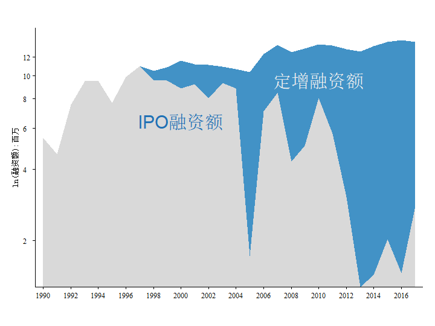

## IPO与定增融资

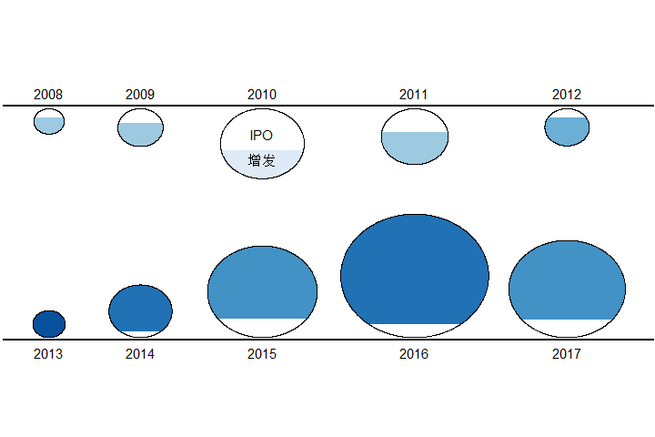

## A股行业分布

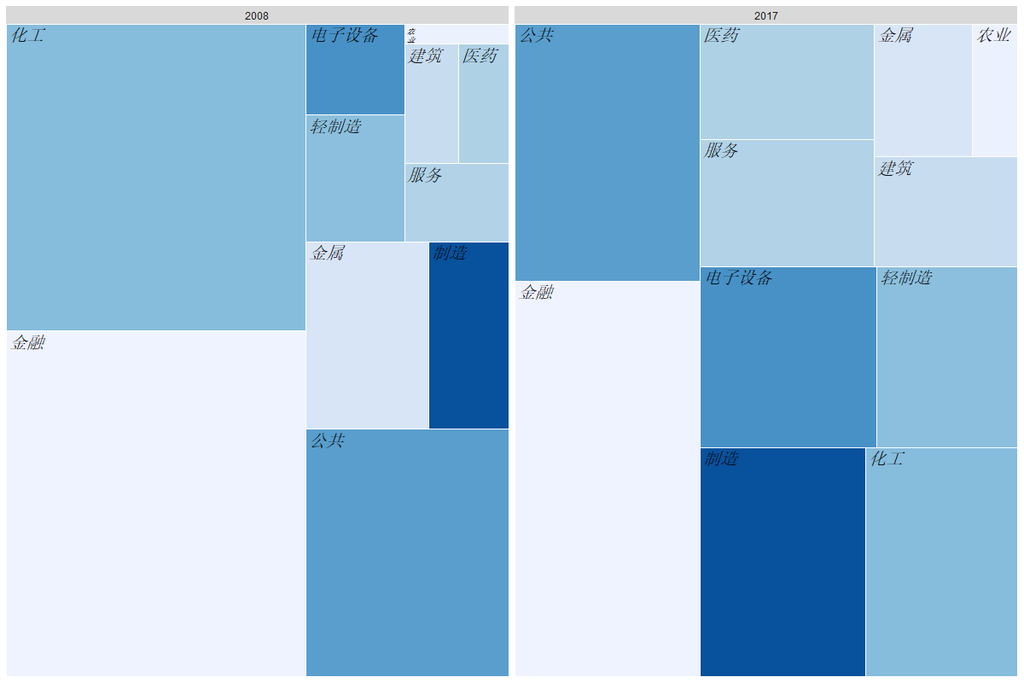

## A股省际分布市值

[interactive chart not shown]

## A股市值-利润

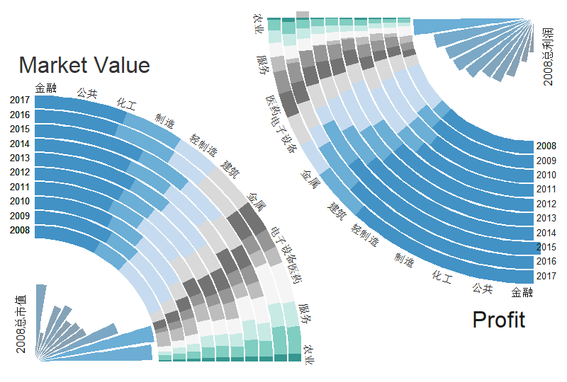

## A股年度涨跌分布

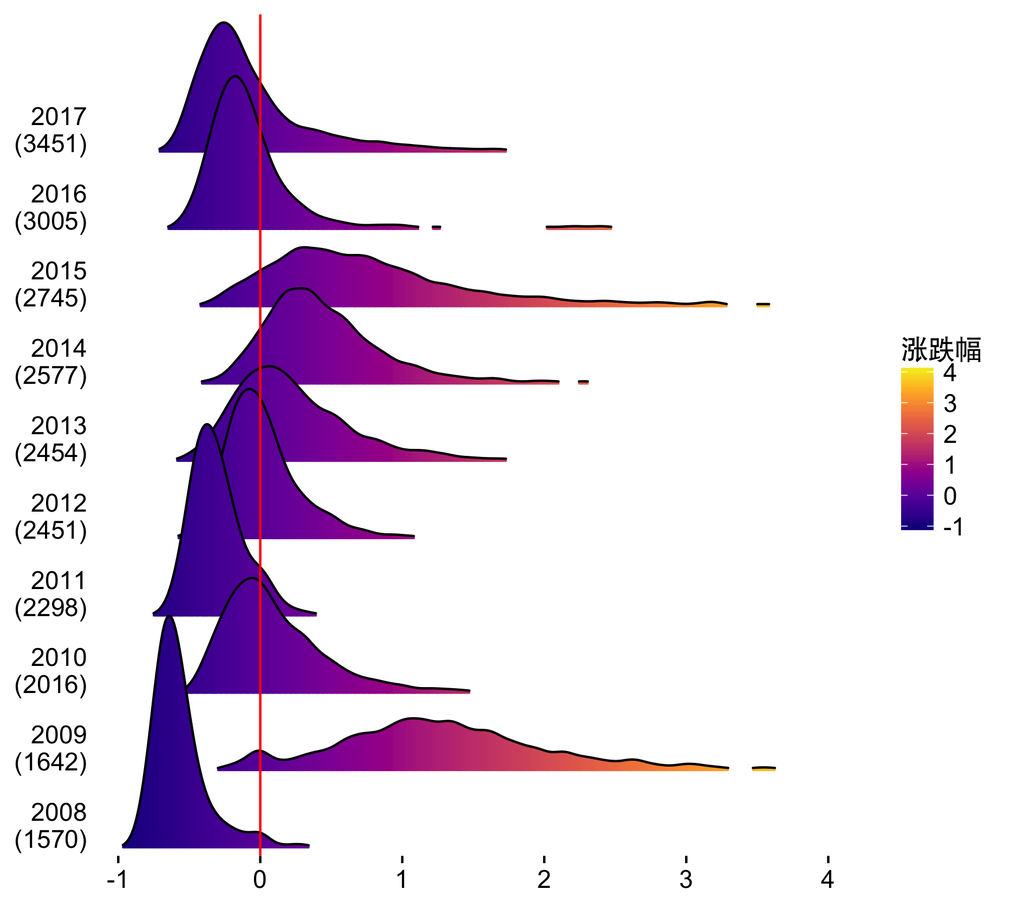

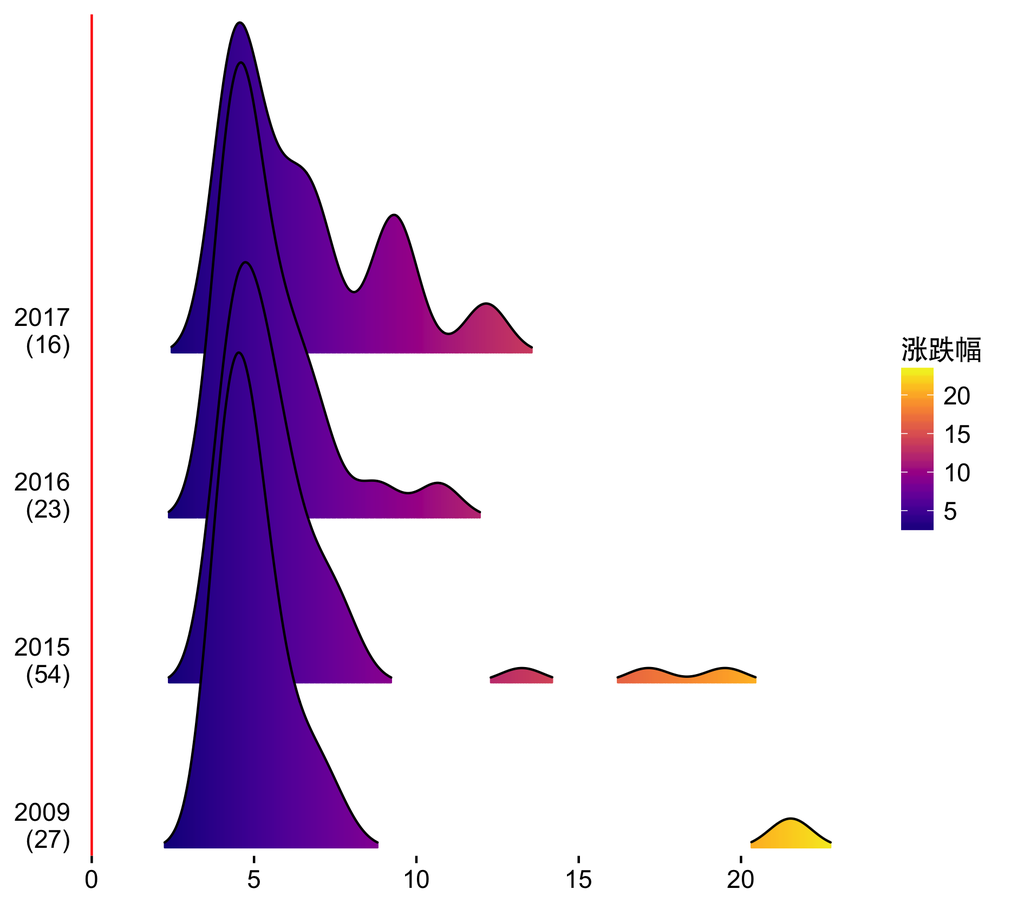

## 涨幅重要性变量

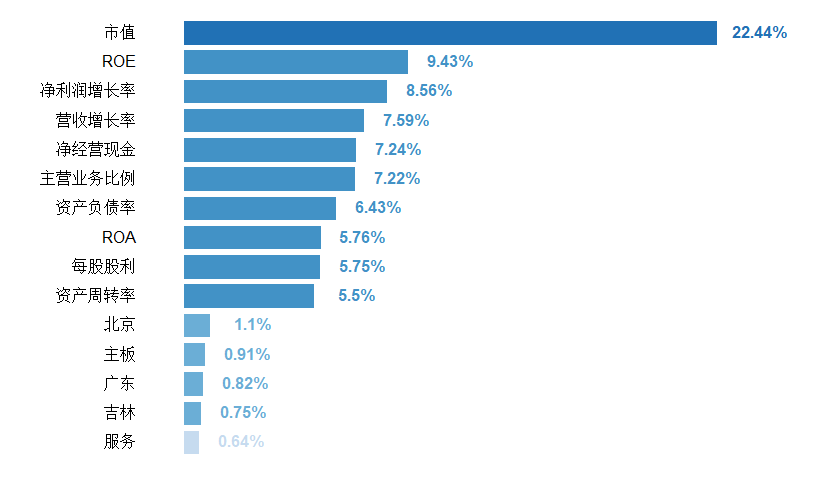

## A股板块热度

[interactive chart not shown]

## 板块涨跌方差分析表

| 年份 | 自由度1 | 自由度2 | F值 | P值 |
| --- | --- | --- | --- | --- |
| 2009 | 2 | 1666 | 142.32 | 8.7e-58 |
| 2010 | 2 | 2014 | 15.49 | 2.1e-07 |
| 2011 | 2 | 2295 | 3.4 | 0.034 |
| 2012 | 2 | 2450 | 21.89 | 3.8e-10 |
| 2013 | 2 | 2452 | 102.94 | 1.2e-43 |
| 2014 | 2 | 2576 | 19.76 | 3e-09 |
| 2015 | 2 | 2799 | 66.17 | 8.3e-29 |
| 2016 | 2 | 3026 | 0.24 | 0.79 |
| 2017 | 2 | 3464 | 2.66 | 0.07 |

## A股十年涨跌榜

| 年份 | 证券简称 | 上市年份 | 涨跌幅(%) | 行业 | 城市 | 上市板 | 总市值(亿) | 净利润增长率(%) |
| --- | --- | --- | --- | --- | --- | --- | --- | --- |
| 2008 | 平潭发展 | 1996 | 410.4413 | 农林牧渔 | 福州市 | 主板 | 2.002 | -78.2757 |
| 2008 | 三安光电 | 1996 | 122.093 | 电子 | 荆州市 | 主板 | 6.4778 | -85.0584 |
| 2008 | 界龙实业 | 1994 | 62.9637 | 轻工制造 | 上海市 | 主板 | 20.73 | -13.3018 |
| 2008 | 隆平高科 | 2000 | 48.6419 | 农林牧渔 | 长沙市 | 主板 | 25.8143 | 38.4379 |
| 2008 | 登海种业 | 2005 | 32.8333 | 农林牧渔 | 莱州市 | 中小企业板 | 21.12 | 58.5388 |
| 2008 | 敦煌种业 | 2004 | 32.073 | 农林牧渔 | 酒泉市 | 主板 | 14.2636 | 495.3207 |
| 2008 | 盘江股份 | 2001 | 31.2334 | 采掘 | 六盘水市 | 主板 | 53.4301 | 441.2119 |
| 2008 | 嘉凯城 | 1999 | 27.7108 | 房地产 | 杭州市 | 主板 | 11.2881 | -96.8667 |
| 2008 | 众合科技 | 1999 | 27.6608 | 机械设备 | 杭州市 | 主板 | 15.813 | -94.3541 |
| 2008 | 小商品城 | 2002 | 26.7434 | 商业贸易 | 义乌市 | 主板 | 108.2103 | 67.3613 |

[output cut: 90 more lines]

## A股十年涨跌榜

| 年份 | 证券简称 | 上市年份 | 涨跌幅(%) | 行业 | 城市 | 上市板 | 总市值(亿) | 净利润增长率(%) |
| --- | --- | --- | --- | --- | --- | --- | --- | --- |
| 2008 | 澳洋科技 | 2007 | -86.9435 | 化工 | 张家港市 | 中小企业板 | 97.3878 | -188.8263 |
| 2008 | 宏达股份 | 2001 | -86.5962 | 有色金属 | 什邡市 | 主板 | 413.832 | -142.3304 |
| 2008 | 山东金泰 | 2001 | -86.2088 | 有色金属 | 济南市 | 主板 | 26.526 | -550.2198 |
| 2008 | 广誉远 | 1996 | -86.0465 | 医药生物 | 西宁市 | 主板 | 49.2737 | 147.8578 |
| 2008 | 景峰医药 | 1999 | -85.4261 | 医药生物 | 岳阳市 | 主板 | 88.116 | -655.0752 |
| 2008 | 中体产业 | 1998 | -85.2775 | 传媒 | 天津市 | 主板 | 276.9351 | 17.4344 |
| 2008 | 云南铜业 | 1998 | -85.2162 | 有色金属 | 昆明市 | 主板 | 688.7911 | -372.177 |
| 2008 | *ST三维 | 1997 | -84.9611 | 化工 | 临汾市 | 主板 | 148.5223 | -99.8001 |
| 2008 | 中国国航 | 2006 | -84.9411 | 交通运输 | 北京市 | 主板 | 2632.2251 | -358.0975 |
| 2008 | 中船防务 | 1993 | -84.7491 | 国防军工 | 广州市 | 主板 | 340.9374 | -12.7044 |

[output cut: 90 more lines]

结论建议